# DiD_analysis_PAs_effect_on_porpoises

Yi Han

2024-07-05

**Email**: yi.han.178@gmail.com  
**Description**: The following code aims to test (1) whether the porpoise abundance was higher and less prone to decline in the PAs than the non-PAs in 2006 and 2017 (Fig 4a & b) and (2) whether the magnitude of abundance decrease is smaller in the PAs (Fig 4c).

## 1. Data preparation

1. Load the file *segment_wise_porpoise_abundance.csv* produced by *analysis_river_lengths_against_abund_ranks.Rmd*

```r
seg_abund_df <- read.csv(file = "../02_percentage_coverage_of_PAs/segment_wise_porpoise_abundance.csv")

group_levels <- seg_abund_df$groups[1:150]
seg_abund <- seg_abund_df %>%
      mutate(reserve = as.factor(reserve),
             reserve_without_nj = as.factor(reserve_without_nj),
             f_year = as.factor(f_year),
             abund_ranks = as.factor(abund_ranks),
             groups = factor(groups, levels=group_levels))
head(seg_abund, 5)
```

```
##    groups f_year year abund_ranks segment_mean reserve reserve_without_nj
## 1  [0,10)   2006 2006    [0,0.05)            0       N                  N
## 2 [10,20)   2006 2006    [0,0.05)            0       N                  N
## 3 [20,30)   2006 2006    [0,0.05)            0       N                  N
## 4 [30,40)   2006 2006    [0,0.05)            0       N                  N
## 5 [40,50)   2006 2006    [0,0.05)            0       N                  N
```

2. Create a new dataframe with each year as a new column and the corresponding segment-wise abundance as inputs.

```r
seg_abund_wide <- seg_abund %>%
    dplyr::select(groups, f_year, segment_mean, reserve, reserve_without_nj) %>%
    tidyr::pivot_wider(., names_from = f_year, values_from = segment_mean)
head(seg_abund_wide, 5)
```

```
## # A tibble: 5 × 5
##   groups  reserve reserve_without_nj `2006` `2017`
##   <fct>   <fct>   <fct>               <dbl>  <dbl>
## 1 [0,10)  N       N                       0 0.095
## 2 [10,20) N       N                       0 0.095
## 3 [20,30) N       N                       0 0.073
## 4 [30,40) N       N                       0 0.0165
## 5 [40,50) N       N                       0 0.005
```

```r
str(seg_abund_wide)
```

```
## tibble [150 × 5] (S3: tbl_df/tbl/data.frame)
##  $ groups            : Factor w/ 150 levels "[0,10)","[10,20)",..: 1 2 3 4 5 6 7 8 9 10 ...
##  $ reserve           : Factor w/ 2 levels "N","Y": 1 1 1 1 1 1 1 1 1 1 ...
##  $ reserve_without_nj: Factor w/ 2 levels "N","Y": 1 1 1 1 1 1 1 1 1 1 ...
##  $ 2006              : num [1:150] 0 0 0 0 0 0 0 0 0 0 ...
##  $ 2017              : num [1:150] 0.095 0.095 0.073 0.0165 0.005 0.005 0.005 0.003 0 0 ...
```

3. Create a new column stores the values of abundance change between 2006 and 2017.

```r
seg_abund_wide <- seg_abund_wide %>%
    rename(abund_06 = "2006",
           abund_17 = "2017") %>%
    mutate(abund_change = abund_17-abund_06)
head(seg_abund_wide, 5)
```

```
## # A tibble: 5 × 6
##   groups  reserve reserve_without_nj abund_06 abund_17 abund_change
##   <fct>   <fct>   <fct>                 <dbl>    <dbl>        <dbl>
## 1 [0,10)  N       N                         0   0.095        0.095
## 2 [10,20) N       N                         0   0.095        0.095
## 3 [20,30) N       N                         0   0.073        0.073
## 4 [30,40) N       N                         0   0.0165       0.0165
## 5 [40,50) N       N                         0   0.005        0.005
```

### Mann–Whitney U test to examine whether the porpoise abundance in the PAs is higher than that in the non-PAs in 2006 with three threshold

```r
thresholds <- c(0.00001, 0.05, 0.1)

for (threshold in thresholds) {
  cat("\n--- Results for Exclusion Abundance < ", threshold, " porpoise km-1 ---\n")

  seg_abund_wide_exl <- seg_abund_wide |>
    filter(!(abund_06 < threshold & abund_17 < threshold))  |>
    droplevels()

  seg_abund_low <- seg_abund_wide %>%
    filter((abund_06 < threshold & abund_17 < threshold))

  cat("Number of Segments excluded\n")
  print(summary(seg_abund_low$reserve))

  abund_06_PA <- seg_abund_wide_exl %>% filter(reserve_without_nj=="Y") %>% pull(abund_06)
  abund_06_nonPA <- seg_abund_wide_exl %>% filter(reserve_without_nj=="N") %>% pull(abund_06)

  outputs_06 <- c(mean(abund_06_PA), sd(abund_06_PA), mean(abund_06_nonPA), sd(abund_06_nonPA))
  names(outputs_06) <- c("abund_06_PA_mean", "abund_06_PA_sd", "abund_06_nonPA_mean", "abund_06_nonPA_sd")

  cat("Statistics for 2006 at threshold ", threshold, ":\n")
  print(outputs_06)
  wilcox_06 <- wilcox.test(abund_06 ~ reserve_without_nj, data=seg_abund_wide_exl)
  cat("Mann–Whitney U test for 2006:\n")
  print(wilcox_06)

  abund_17_PA <- seg_abund_wide_exl %>% filter(reserve=="Y") %>% pull(abund_17)
  abund_17_nonPA <- seg_abund_wide_exl %>% filter(reserve=="N") %>% pull(abund_17)

  outputs_17 <- c(mean(abund_17_PA), sd(abund_17_PA), mean(abund_17_nonPA), sd(abund_17_nonPA))
  names(outputs_17) <- c("abund_17_PA_mean", "abund_17_PA_sd", "abund_17_nonPA_mean", "abund_17_nonPA_sd")

  cat("Statistics for 2017 at threshold ", threshold, ":\n")
  print(outputs_17)
  wilcox_17 <- wilcox.test(abund_17 ~ reserve, data=seg_abund_wide_exl)
  cat("Mann–Whitney U test for 2017:\n")
  print(wilcox_17)
}
```

```
##
## --- Results for Exclusion Abundance <  1e-05  porpoise km-1 ---
## Number of Segments excluded
## N Y
## 5 0
## Statistics for 2006 at threshold  1e-05 :
##    abund_06_PA_mean      abund_06_PA_sd abund_06_nonPA_mean   abund_06_nonPA_sd
##           0.2036563           0.1957523           0.1425052           0.1321653
## Mann–Whitney U test for 2006:
##
##  Wilcoxon rank sum test with continuity correction
##
## data:  abund_06 by reserve_without_nj
## W = 1951.5, p-value = 0.1139
## alternative hypothesis: true location shift is not equal to 0
##
## Statistics for 2017 at threshold  1e-05 :
##    abund_17_PA_mean      abund_17_PA_sd abund_17_nonPA_mean   abund_17_nonPA_sd
##          0.11984906          0.11299569          0.09888587          0.10606838
## Mann–Whitney U test for 2017:
##
##  Wilcoxon rank sum test with continuity correction
##
## data:  abund_17 by reserve
## W = 2110.5, p-value = 0.1794
## alternative hypothesis: true location shift is not equal to 0
##
##
## --- Results for Exclusion Abundance <  0.05  porpoise km-1 ---
## Number of Segments excluded
##  N  Y
## 21  8
## Statistics for 2006 at threshold  0.05 :
##    abund_06_PA_mean      abund_06_PA_sd abund_06_nonPA_mean   abund_06_nonPA_sd
##           0.2398250           0.1950589           0.1669444           0.1312602
## Mann–Whitney U test for 2006:
##
##  Wilcoxon rank sum test with continuity correction
##
## data:  abund_06 by reserve_without_nj
```

[output cut: 25 more lines]

```
##
## data:  abund_06 by reserve_without_nj
## W = 714.5, p-value = 0.01632
## alternative hypothesis: true location shift is not equal to 0
##
## Statistics for 2017 at threshold  0.1 :
##    abund_17_PA_mean      abund_17_PA_sd abund_17_nonPA_mean   abund_17_nonPA_sd
##           0.1548378           0.1184423           0.1349153           0.1152149
## Mann–Whitney U test for 2017:
##
##  Wilcoxon rank sum test with continuity correction
##
## data:  abund_17 by reserve
## W = 982, p-value = 0.4119
## alternative hypothesis: true location shift is not equal to 0
```

## Difference-in-difference analysis

### Threshold: excluding river segments with 0 porpoise km-1 in both 2006 and 2017.

```r
threshold <- 0.000001

seg_abund_wide_exl <- seg_abund_wide |>
    filter(!(abund_06 < threshold & abund_17 < threshold))  |>
    droplevels()
# str(seg_abund_wide_exl)
```

```r
# seg_abund_wide_exl

seg_abund_wide_exl_long <- seg_abund_wide_exl |>
  dplyr::select(groups, abund_06, abund_17, reserve) |>
  pivot_longer(
    cols = starts_with("abund"),
    names_to = "year",
    values_to = "abundance"
  ) |>
  mutate(year = recode(year, abund_06 = "2006", abund_17 = "2017"))

# seg_abund_wide_exl_long
```

```r
# Create the binary variables for DID
seg_abund_wide_exl_binary <- seg_abund_wide_exl_long %>%
  mutate(
    PA = ifelse(reserve == "Y", 1, 0),
    Post = ifelse(year == 2017, 1, 0)
  )
head(seg_abund_wide_exl_binary)
```

```
## # A tibble: 6 × 6
##   groups  reserve year  abundance    PA  Post
##   <fct>   <fct>   <chr>     <dbl> <dbl> <dbl>
## 1 [0,10)  N       2006      0         0     0
## 2 [0,10)  N       2017      0.095     0     1
## 3 [10,20) N       2006      0         0     0
## 4 [10,20) N       2017      0.095     0     1
## 5 [20,30) N       2006      0         0     0
## 6 [20,30) N       2017      0.073     0     1
```

```r
did_model <- lm(abundance ~ PA + Post + PA:Post, data = seg_abund_wide_exl_binary)
summary(did_model)
```

```
##
## Call:
## lm(formula = abundance ~ PA + Post + PA:Post, data = seg_abund_wide_exl_binary)
##
## Residuals:
##      Min       1Q   Median       3Q      Max
## -0.21308 -0.08916 -0.02739  0.05309  0.55692
##
## Coefficients:
##             Estimate Std. Error t value Pr(>|t|)
## (Intercept)  0.13375    0.01389   9.631  < 2e-16 ***
## PA           0.07933    0.02297   3.454 0.000636 ***
## Post        -0.03486    0.01964  -1.775 0.076917 .
## PA:Post     -0.05837    0.03248  -1.797 0.073395 .
## ---
## Signif. codes:  0 '***' 0.001 '**' 0.01 '*' 0.05 '.' 0.1 ' ' 1
##
## Residual standard error: 0.1332 on 286 degrees of freedom
## Multiple R-squared:  0.08236,    Adjusted R-squared:  0.07274
## F-statistic: 8.557 on 3 and 286 DF,  p-value: 1.849e-05
```

```r
library(sandwich)
library(lmtest)
library(zoo)
coeftest(did_model, vcov = vcovHC(did_model, type = "HC1"))
```

```
##
## t test of coefficients:
##
##              Estimate Std. Error t value  Pr(>|t|)
## (Intercept)  0.133750   0.013439  9.9520 < 2.2e-16 ***
## PA           0.079335   0.029305  2.7072  0.007193 **
## Post        -0.034864   0.017415 -2.0020  0.046229 *
## PA:Post     -0.058372   0.034944 -1.6704  0.095927 .
## ---
## Signif. codes:  0 '***' 0.001 '**' 0.01 '*' 0.05 '.' 0.1 ' ' 1
```

```r
# Creating a data frame from your model output
results <- data.frame(
  Term = c("Intercept", "PA", "Post", "PA:Post"),
  Estimate = round(c(0.13375, 0.079335, -0.034864, -0.058372), 4),
  `Std Error` = round(c(0.013439, 0.029305, 0.017415, 0.034944), 4),
  `t value` = round(c(9.9520, 2.7072, -2.0020, -1.6704), 4),
  `p-value` = c("< 2.2e-16", "0.0072", "0.0462", "0.0959")
)
results$Significance <- c("***", "**", "*", ".")

kable(results, format = "html", caption = "Statistical Results of Difference-in-Differences Analysis")
```

Statistical Results of Difference-in-Differences Analysis

Term

Estimate

Std.Error

t.value

p.value

Significance

Intercept

0.1338

0.0134

9.9520

< 2.2e-16

***

PA

0.0793

0.0293

2.7072

0.0072

Post

-0.0349

0.0174

-2.0020

0.0462

PA:Post

-0.0584

0.0349

-1.6704

0.0959

.

```r
results_table <- kable(results, format = "html", booktabs = TRUE,
                       caption = "Statistical Results of Difference-in-Differences Analysis") %>%
  kable_styling(bootstrap_options = c("striped", "hover", "condensed"), full_width = FALSE) %>%
  column_spec(1, bold = TRUE) %>% # Make the first column bold
  column_spec(5, color = "red") # Change the color for p-values for emphasis

# To display the table in R Markdown or output it to an HTML report
results_table
```

Statistical Results of Difference-in-Differences Analysis

Term

Estimate

Std.Error

t.value

p.value

Significance

Intercept

0.1338

0.0134

9.9520

< 2.2e-16

***

PA

0.0793

0.0293

2.7072

0.0072

Post

-0.0349

0.0174

-2.0020

0.0462

PA:Post

-0.0584

0.0349

-1.6704

0.0959

.

### Threshold: excluding river segments with porpoise abundance < 0.05 porpoise km-1 in both 2006 and 2017.

```r
threshold <- 0.05

seg_abund_wide_exl <- seg_abund_wide |>
    filter(!(abund_06 < threshold & abund_17 < threshold))  |>
    droplevels()
# str(seg_abund_wide_exl)
```

```r
# seg_abund_wide_exl

seg_abund_wide_exl_long <- seg_abund_wide_exl |>
  dplyr::select(groups, abund_06, abund_17, reserve) |>
  pivot_longer(
    cols = starts_with("abund"),
    names_to = "year",
    values_to = "abundance"
  ) |>
  mutate(year = recode(year, abund_06 = "2006", abund_17 = "2017"))

# seg_abund_wide_exl_long
```

```r
# Create the binary variables for DID
seg_abund_wide_exl_binary <- seg_abund_wide_exl_long %>%
  mutate(
    PA = ifelse(reserve == "Y", 1, 0),
    Post = ifelse(year == 2017, 1, 0)
  )
head(seg_abund_wide_exl_binary)
```

```
## # A tibble: 6 × 6
##   groups  reserve year  abundance    PA  Post
##   <fct>   <fct>   <chr>     <dbl> <dbl> <dbl>
## 1 [0,10)  N       2006      0         0     0
## 2 [0,10)  N       2017      0.095     0     1
## 3 [10,20) N       2006      0         0     0
## 4 [10,20) N       2017      0.095     0     1
## 5 [20,30) N       2006      0         0     0
## 6 [20,30) N       2017      0.073     0     1
```

```r
did_model <- lm(abundance ~ PA + Post + PA:Post, data = seg_abund_wide_exl_binary)
summary(did_model)
```

```
##
## Call:
## lm(formula = abundance ~ PA + Post + PA:Post, data = seg_abund_wide_exl_binary)
##
## Residuals:
##      Min       1Q   Median       3Q      Max
## -0.24691 -0.09078 -0.03120  0.05285  0.52309
##
## Coefficients:
##             Estimate Std. Error t value Pr(>|t|)
## (Intercept)  0.15795    0.01530  10.326  < 2e-16 ***
## PA           0.08896    0.02508   3.546  0.00047 ***
## Post        -0.04116    0.02163  -1.902  0.05832 .
## PA:Post     -0.06849    0.03547  -1.931  0.05472 .
## ---
## Signif. codes:  0 '***' 0.001 '**' 0.01 '*' 0.05 '.' 0.1 ' ' 1
##
## Residual standard error: 0.1334 on 238 degrees of freedom
## Multiple R-squared:  0.1064, Adjusted R-squared:  0.09515
## F-statistic: 9.448 on 3 and 238 DF,  p-value: 6.376e-06
```

```r
coeftest(did_model, vcov = vcovHC(did_model, type = "HC1"))
```

```
##
## t test of coefficients:
##
##              Estimate Std. Error t value  Pr(>|t|)
## (Intercept)  0.157954   0.014813 10.6634 < 2.2e-16 ***
## PA           0.088957   0.031462  2.8274  0.005092 **
## Post        -0.041158   0.019349 -2.1271  0.034442 *
## PA:Post     -0.068487   0.037840 -1.8099  0.071574 .
## ---
## Signif. codes:  0 '***' 0.001 '**' 0.01 '*' 0.05 '.' 0.1 ' ' 1
```

```r
# Creating a data frame from your model output
results <- data.frame(
  Term = c("Intercept", "PA", "Post", "PA:Post"),
  Estimate = round(c(0.157954, 0.088957, -0.041158, -0.068487), 4),
  `Std Error` = round(c(0.014813, 0.031462, 0.019349, 0.037840), 4),
  `t value` = round(c(10.6634, 2.8274, -2.1271, -1.8099), 4),
  `p-value` = c("< 2.2e-16", "0.0051", "0.0344", "0.0716")
)
results$Significance <- c("***", "**", "*", ".")

kable(results, format = "html", caption = "Statistical Results of Difference-in-Differences Analysis")
```

Statistical Results of Difference-in-Differences Analysis

Term

Estimate

Std.Error

t.value

p.value

Significance

Intercept

0.1580

0.0148

10.6634

< 2.2e-16

***

PA

0.0890

0.0315

2.8274

0.0051

Post

-0.0412

0.0193

-2.1271

0.0344

PA:Post

-0.0685

0.0378

-1.8099

0.0716

.

```r
results_table <- kable(results, format = "html", booktabs = TRUE,
                       caption = "Statistical Results of Difference-in-Differences Analysis") %>%
  kable_styling(bootstrap_options = c("striped", "hover", "condensed"), full_width = FALSE) %>%
  column_spec(1, bold = TRUE) %>% # Make the first column bold
  column_spec(5, color = "red") # Change the color for p-values for emphasis

# To display the table in R Markdown or output it to an HTML report
results_table
```

Statistical Results of Difference-in-Differences Analysis

Term

Estimate

Std.Error

t.value

p.value

Significance

Intercept

0.1580

0.0148

10.6634

< 2.2e-16

***

PA

0.0890

0.0315

2.8274

0.0051

Post

-0.0412

0.0193

-2.1271

0.0344

PA:Post

-0.0685

0.0378

-1.8099

0.0716

.

### Threshold: excluding river segments with porpoise abundance < 0.1 porpoise km-1 in both 2006 and 2017.

```r
threshold <- 0.1

seg_abund_wide_exl <- seg_abund_wide |>
    filter(!(abund_06 < threshold & abund_17 < threshold))  |>
    droplevels()
# str(seg_abund_wide_exl)
```

```r
# seg_abund_wide_exl

seg_abund_wide_exl_long <- seg_abund_wide_exl |>
  dplyr::select(groups, abund_06, abund_17, reserve) |>
  pivot_longer(
    cols = starts_with("abund"),
    names_to = "year",
    values_to = "abundance"
  ) |>
  mutate(year = recode(year, abund_06 = "2006", abund_17 = "2017"))

# seg_abund_wide_exl_long
```

```r
# Create the binary variables for DID
seg_abund_wide_exl_binary <- seg_abund_wide_exl_long %>%
  mutate(
    PA = ifelse(reserve == "Y", 1, 0),
    Post = ifelse(year == 2017, 1, 0)
  )
head(seg_abund_wide_exl_binary)
```

```
## # A tibble: 6 × 6
##   groups    reserve year  abundance    PA  Post
##   <fct>     <fct>   <chr>     <dbl> <dbl> <dbl>
## 1 [170,180) N       2006     0.126      0     0
## 2 [170,180) N       2017     0.01       0     1
## 3 [180,190) N       2006     0.145      0     0
## 4 [180,190) N       2017     0.0385     0     1
## 5 [190,200) N       2006     0.128      0     0
## 6 [190,200) N       2017     0.036      0     1
```

```r
did_model <- lm(abundance ~ PA + Post + PA:Post, data = seg_abund_wide_exl_binary)
summary(did_model)
```

```
##
## Call:
## lm(formula = abundance ~ PA + Post + PA:Post, data = seg_abund_wide_exl_binary)
##
## Residuals:
##      Min       1Q   Median       3Q      Max
## -0.19018 -0.09127 -0.03493  0.06052  0.47803
##
## Coefficients:
##             Estimate Std. Error t value Pr(>|t|)
## (Intercept)  0.19018    0.01732  10.978  < 2e-16 ***
## PA           0.10180    0.02790   3.648 0.000342 ***
## Post        -0.05526    0.02450  -2.256 0.025243 *
## PA:Post     -0.08187    0.03946  -2.075 0.039380 *
## ---
## Signif. codes:  0 '***' 0.001 '**' 0.01 '*' 0.05 '.' 0.1 ' ' 1
##
## Residual standard error: 0.1331 on 188 degrees of freedom
## Multiple R-squared:  0.1541, Adjusted R-squared:  0.1406
## F-statistic: 11.42 on 3 and 188 DF,  p-value: 6.522e-07
```

```r
coeftest(did_model, vcov = vcovHC(did_model, type = "HC1"))
```

```
##
## t test of coefficients:
##
##              Estimate Std. Error t value  Pr(>|t|)
## (Intercept)  0.190178   0.016708 11.3827 < 2.2e-16 ***
## PA           0.101795   0.033190  3.0671  0.002481 **
## Post        -0.055263   0.022473 -2.4591  0.014833 *
## PA:Post     -0.081872   0.041282 -1.9833  0.048794 *
## ---
## Signif. codes:  0 '***' 0.001 '**' 0.01 '*' 0.05 '.' 0.1 ' ' 1
```

```r
# Creating a data frame from your model output
results <- data.frame(
  Term = c("Intercept", "PA", "Post", "PA:Post"),
  Estimate = round(c(0.190178, 0.101795, -0.055263, -0.081872), 4),
  `Std Error` = round(c(0.016708, 0.033190, 0.022473, 0.041282), 4),
  `t value` = round(c(11.3827, 3.0671, -2.4591, -1.9833), 4),
  `p value` = c("< 2.2e-16", "0.0025", "0.0148", "0.0488")
)
results$Significance <- c("***", "**", "*", ".")

kable(results, format = "html", caption = "Statistical Results of Difference-in-Differences Analysis")
```

Statistical Results of Difference-in-Differences Analysis

Term

Estimate

Std.Error

t.value

p.value

Significance

Intercept

0.1902

0.0167

11.3827

< 2.2e-16

***

PA

0.1018

0.0332

3.0671

0.0025

Post

-0.0553

0.0225

-2.4591

0.0148

PA:Post

-0.0819

0.0413

-1.9833

0.0488

.

```r
results_table <- kable(results, format = "html", booktabs = TRUE,
                       caption = "Statistical Results of Difference-in-Differences Analysis") %>%
  kable_styling(bootstrap_options = c("striped", "hover", "condensed"), full_width = FALSE) %>%
  column_spec(1, bold = TRUE) %>% # Make the first column bold
  column_spec(5, color = "red") # Change the color for p-values for emphasis

# To display the table in R Markdown or output it to an HTML report
results_table
```

Statistical Results of Difference-in-Differences Analysis

Term

Estimate

Std.Error

t.value

p.value

Significance

Intercept

0.1902

0.0167

11.3827

< 2.2e-16

***

PA

0.1018

0.0332

3.0671

0.0025

Post

-0.0553

0.0225

-2.4591

0.0148

PA:Post

-0.0819

0.0413

-1.9833

0.0488

.

### Plotting

**Plot porpoise abundance in 2006 (PAs v.s. non-PAs)**

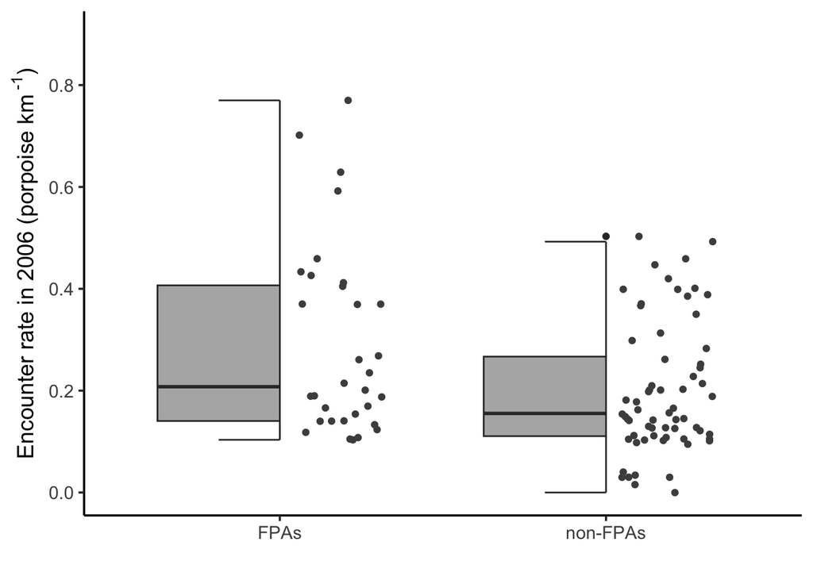

```r
abund_06 <- ggplot(seg_abund_wide_exl, aes(x = reserve_without_nj, y=abund_06)) +
    geom_half_boxplot(fill="grey70")+
    geom_half_point(color="grey30")+
    scale_y_continuous(limits = c(0, 0.9), breaks=seq(0, 0.9, 0.2)) +
    scale_x_discrete(limits = c("Y", "N"),
                     breaks = c("Y", "N"),
                     labels = c("FPAs", "non-FPAs")) +
    labs (x = "", y = expression(paste("Encounter rate in 2006 ", "(", "porpoise km"^" -1", ")"))) +
    theme_classic(base_size = 14) +
    theme(legend.position.inside = c(.99, .99),
          legend.justification = c("right", "top"),
          legend.box.just = "right")
abund_06
```

**Plot porpoise abundance in 2017 (PAs v.s. non-PAs)**

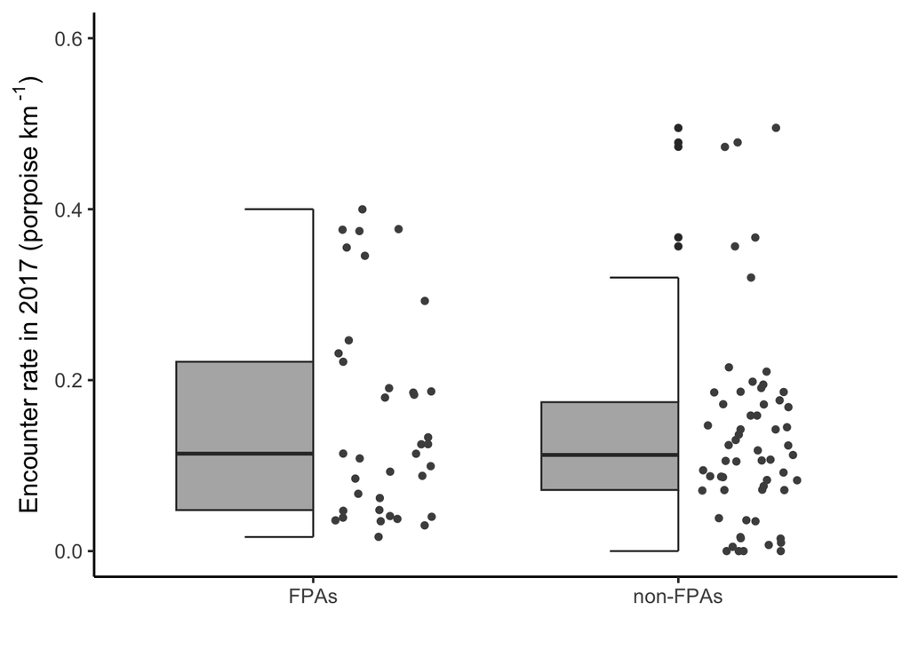

```r
abund_17 <- ggplot(seg_abund_wide_exl, aes(x = reserve, y=abund_17)) +
    geom_half_boxplot(fill="grey70")+
    geom_half_point(color="grey30")+
    scale_y_continuous(limits = c(0, 0.6), breaks=seq(0, 0.6, 0.2)) +
    scale_x_discrete(limits = c("Y", "N"),
                     breaks = c("Y", "N"),
                     labels = c("FPAs", "non-FPAs")) +
    labs (x = "", y = expression(paste("Encounter rate in 2017 ", "(", "porpoise km"^" -1", ")"))) +
    theme_classic(base_size = 14) +
    theme(legend.position = c(.99, .99),
          legend.justification = c("right", "top"),
          legend.box.just = "right")
abund_17
```

**Plot DiD analysis results**

```r
data_summary <- seg_abund_wide_exl_binary %>%
  group_by(PA, year) %>%
  summarise(Abundance = mean(abundance), .groups = 'drop') |>
  mutate()

data_summary
```

```
## # A tibble: 4 × 3
##      PA year  Abundance
##   <dbl> <chr>     <dbl>
## 1     0 2006      0.190
## 2     0 2017      0.135
## 3     1 2006      0.292
## 4     1 2017      0.155
```

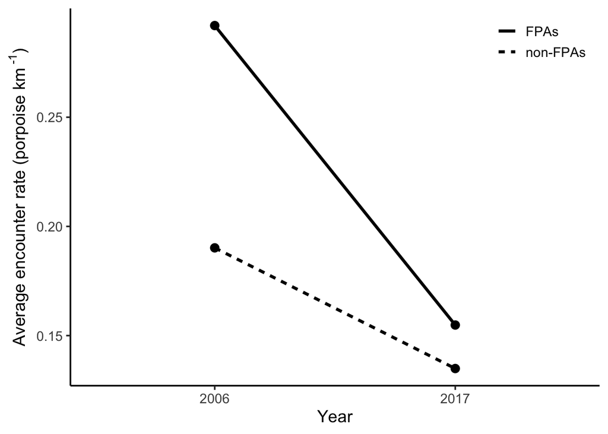

```r
data <- data.frame(
  Group = rep(c("FPAs", "non-FPAs"), each = 2),
  Year = rep(c("2006", "2017"), 2),
  Abundance = c(0.2919730, 0.1548378, 0.1901780, 0.1349153)  # Sample mean values
)

abund_change <- ggplot(data, aes(x = Year, y = Abundance, group = Group)) +
  geom_line(aes(linetype = Group), size = 1.2) +
  geom_point(size = 3) +
  # scale_color_manual(values = c("FPA" = "black", "non-FPA" = "black")) +
  labs(x = "Year",
       y = expression(paste("Average encounter rate ", "(", "porpoise km"^" -1", ")"))
       ) +
  theme_classic(base_size = 14) +
  theme(legend.position = c(.99, .99),
        legend.justification = c("right", "top"),
        legend.box.just = "right",
        legend.title = element_blank())
abund_change
```

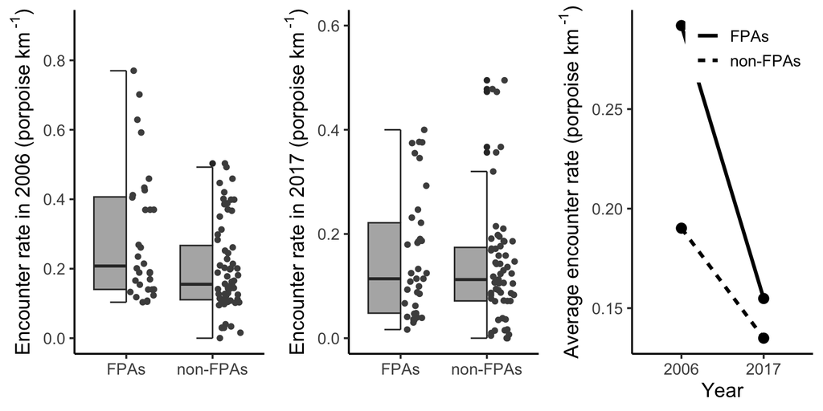

```r
combined_plot <- grid.arrange(abund_06, abund_17, abund_change, ncol = 3)
```

```r
combined_plot
```

```r
ggsave("combined_plots.png", combined_plot, width = 12, height = 4)
```